# B stim Data using kallisto | tximport | DESeq2 pipeline

Diego A. Espinoza

Compiled on 13 August 2021

# Loading the data from kallisto output

In summary, B cells from 3 patients underwent 3 stimulation conditions or nil. They were: BCR stim, CD40L stim, CD40L + BCR stim. These 3 conditions plus a non-stimulated control were then used for RNA-seq (12 samples total). Data was pseudoaligned to the human transcriptome using kallisto. Here we will load data output from the kallisto run. We will use tximport to load our data into DESeq2, where we will then perform differential expression analysis.

```r
#get metadata
metadata_path <- "stim_metadata.xlsx"
bstim_metadata <- readxl::read_excel(path = metadata_path) %>%
  dplyr::mutate(patient = factor(patient, levels = c("D1", "D2", "D3")),
         activation = factor(activation, levels = c("Nil",
                                                    "CD40L",
                                                    "CD40L_BCR",
                                                    "BCR")))

#load abundances from h5 files output from kallisto
parent_directory <- "kallisto_output"
kallisto_directories <- list.files(parent_directory, full.names = TRUE) %>%
  grep(pattern = "L00N", value = TRUE) %>%
  paste0(., "/abundance.h5")
kallisto_directories <- kallisto_directories[kallisto_directories %in% paste0(parent_directory, "/", bstim_metadata$filename, "/abundance.h5")]
kallisto_sample_names <- list.files(parent_directory, full.names = FALSE) %>%
  grep(pattern = "L00N", value = TRUE)
kallisto_sample_names <- kallisto_sample_names[kallisto_sample_names %in% bstim_metadata$filename]

names(kallisto_directories) <- kallisto_sample_names

#load transcript to gene_id dataframe from database build step
tx_df <- read.csv("gencode_v33_master.csv", stringsAsFactors = FALSE)
tx_df <- tx_df[,c("tx_id", "gene_id")]

#use tximport to set data up for input into deseq2
txi_kallisto <- tximport::tximport(kallisto_directories, type = "kallisto", ignoreTxVersion = TRUE, tx2gene = tx_df)

#import data from tximport into DESeq2, setting the patient as a covariate and the celltype_treatment level as the factor being tested (can draw different contrasts from this later)
bstim_dds <- DESeq2::DESeqDataSetFromTximport(txi_kallisto, bstim_metadata %>% as_tibble(), design = ~patient+activation)

#build DESeq2 model using all samples
bstim_dds <- DESeq2::DESeq(bstim_dds)

#this gene table will be used to convert ensembl IDs into gene names for usage with other data sources
gene_table <-  read.csv("gencode_v33_master_concatenated.csv", stringsAsFactors = FALSE) %>% select(gene_id, gene_name, entrez_id)
```

# Differential expression analysis using DESeq2

We next perform a list of comparisions using DESeq2. We will compare all our stimulation conditions to the Nil (no stim) condition.

```r
comparisons <- list(c("activation", "CD40L", "Nil"),
                    c("activation", "BCR", "Nil"),
                    c("activation", "CD40L_BCR", "Nil"))
comparisons_strings <- lapply(comparisons, function(x){paste0(x[2], " vs ", x[3])}) %>% unlist

bstim_dds_results <- lapply(1:length(comparisons), function(i){
  return(results(bstim_dds, contrast = comparisons[[i]]))
})

bstim_dds_results_df <- lapply(1:length(bstim_dds_results), function(i){
  bstim_dds_results[[i]] %>%
    as.data.frame %>%
    rownames_to_column(var = "gene_id") %>%
    dplyr::mutate(comparison = comparisons_strings[i]) %>%
    left_join(gene_table, by = "gene_id")
})
names(bstim_dds_results_df) <- c("LvN", "BvN", "CSvN")

bstim_rlog <- rlog(bstim_dds, blind = TRUE)
```

## PCA plots

We next plot our samples on PCs 1, 2, 3, and 4 (PCA was performed on the rlog values).

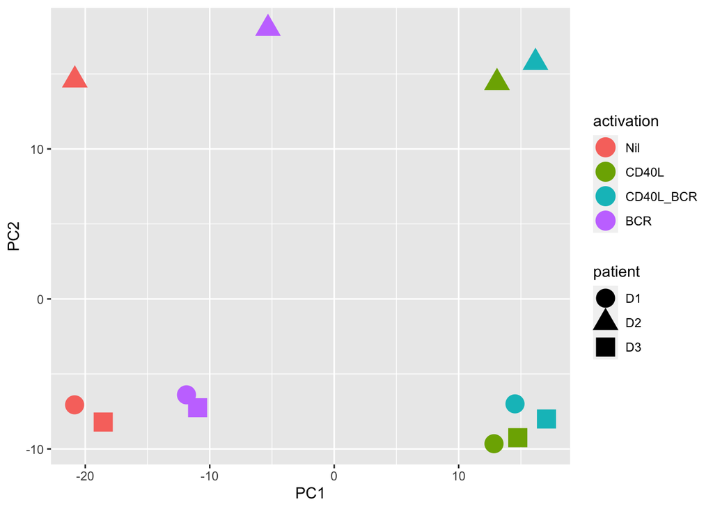

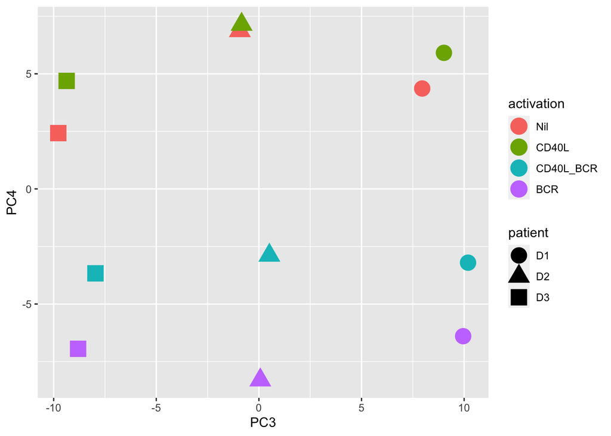

```r
names(assays(bstim_rlog)) <- "rlog"
plotPCA_from_online(bstim_rlog, assay_choice = "rlog", intgroup=c("activation", "patient"), returnData = TRUE) -> x
ggplot(x, aes(x = PC1, y = PC2, color = activation, shape = patient))+geom_point(size = 6)
ggplot(x, aes(x = PC3, y = PC4, color = activation, shape = patient))+geom_point(size = 6)
```

## MA Plots

```r
plot_list <- lapply(1:length(bstim_dds_results_df), function(i){
  plot_1 <- sig_MA_plot(bstim_dds_results_df[[i]], title = bstim_dds_results_df[[i]]$comparison, p_val_choice = 0.01, log2FC_choice = 1, label_top_genes = 20)
  return(plot_1)
})
cowplot::plot_grid(plotlist = plot_list, ncol = 1)
```

[output not shown]

## DE genes

```r
#set significance cutoff for adjusted p-values
significance_cutoff <- 0.05

#get relevant comparisons
CSvN <- bstim_dds_results_df$CSvN %>%dplyr::rename_at(vars(!contains('gene')), ~paste0("CSvN_", .))
BvN <- bstim_dds_results_df$BvN %>%dplyr::rename_at(vars(!contains('gene')), ~paste0("BvN_", .))
LvN <- bstim_dds_results_df$LvN %>% dplyr::rename_at(vars(!contains('gene')), ~paste0("LvN_", .))

#join the comparisons together
LvN %>%
  dplyr::left_join(CSvN, by = c("gene_id","gene_name")) %>%
  dplyr::left_join(BvN, by = c("gene_id","gene_name")) -> joined_comparisons

joined_comparisons %>%
  dplyr::filter(LvN_padj < significance_cutoff) %>%
  dplyr::filter(LvN_log2FoldChange > 0) -> L_UP

joined_comparisons %>%
  dplyr::filter(CSvN_padj < significance_cutoff) %>%
  dplyr::filter(CSvN_log2FoldChange > 0) -> CS_UP

joined_comparisons %>%
  dplyr::filter(BvN_padj < significance_cutoff) %>%
  dplyr::filter(BvN_log2FoldChange > 0) -> B_UP


L_UP %>%
  dplyr::filter(!((BvN_log2FoldChange > 0) & (BvN_padj < significance_cutoff))) %>%
  dplyr::filter(!((CSvN_log2FoldChange > 0) & (CSvN_padj < significance_cutoff))) -> L_UP_ONLY

B_UP %>%
  dplyr::filter(!((LvN_log2FoldChange > 0) & (LvN_padj < significance_cutoff))) %>%
  dplyr::filter(!((CSvN_log2FoldChange > 0) & (CSvN_padj < significance_cutoff))) -> B_UP_ONLY


L_UP_only_genes <- unique(L_UP_ONLY$gene_name)
L_UP_only_genes <- L_UP_only_genes[!is.na(L_UP_only_genes)]
B_UP_only_genes <- unique(B_UP_ONLY$gene_name)
B_UP_only_genes <- B_UP_only_genes[!is.na(B_UP_only_genes)]
CS_UP_genes <- unique(CS_UP$gene_name)
```

## Finding gene signatures.

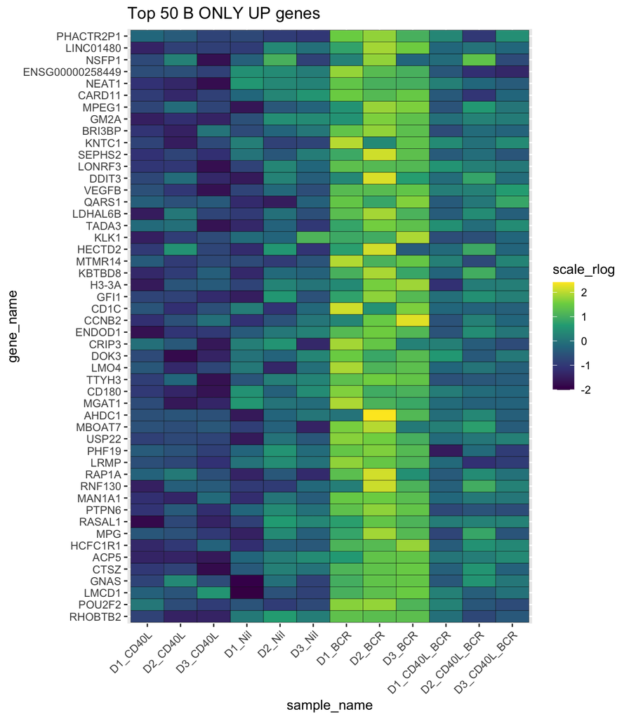

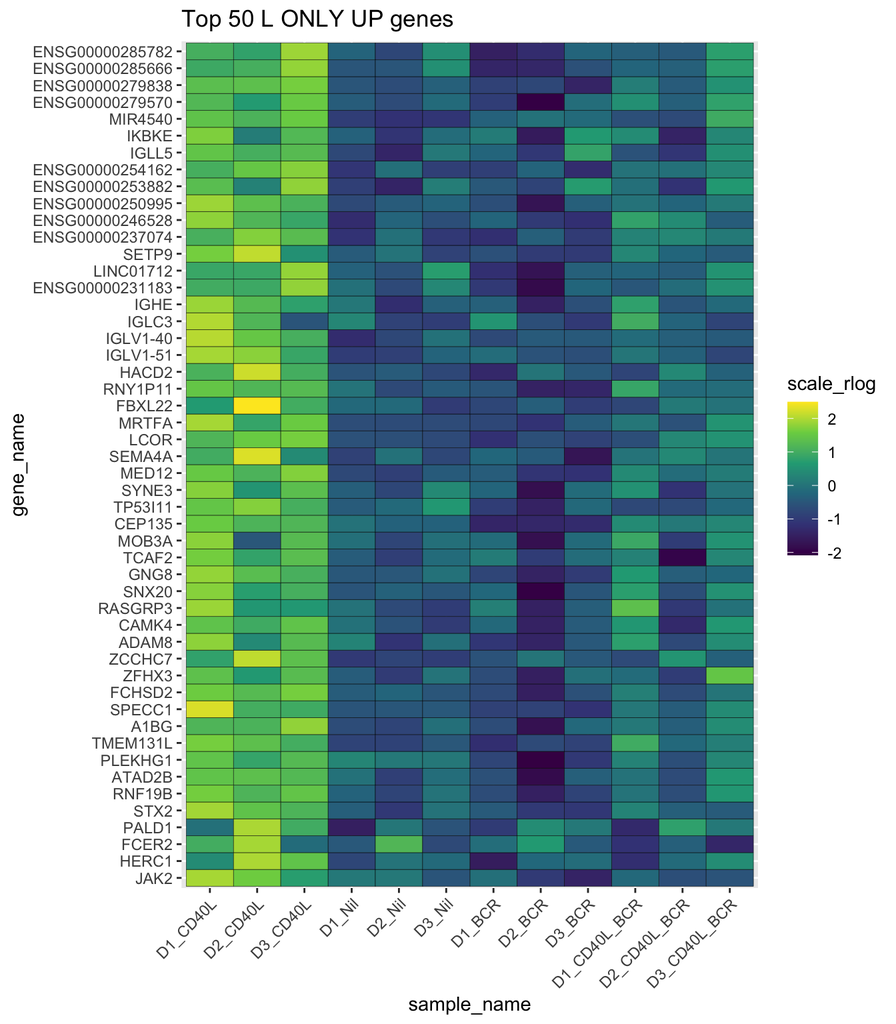

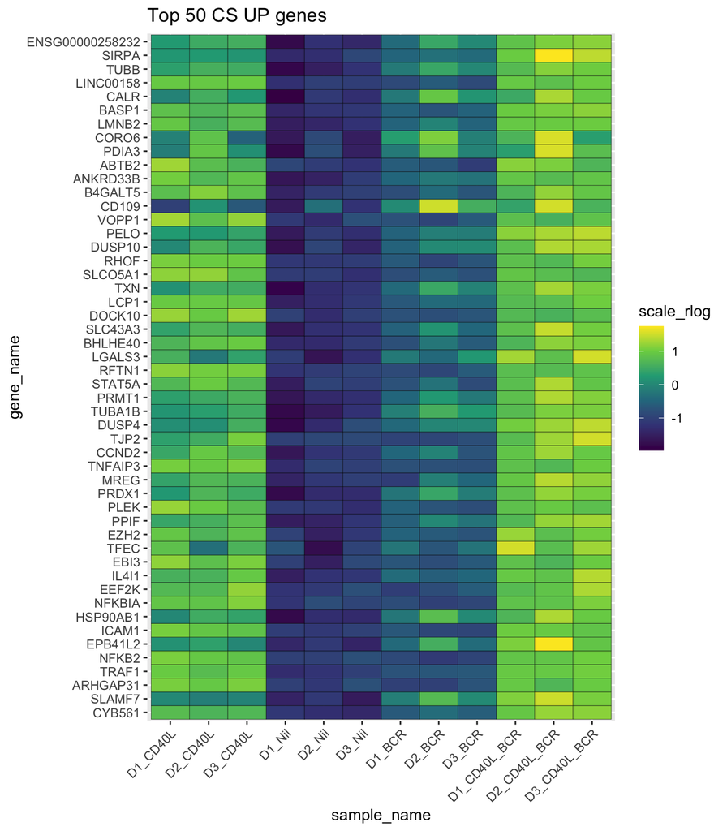

```r
as.data.frame(assay(bstim_rlog)) %>% rownames_to_column(var = "gene_id") %>% pivot_longer(cols = -gene_id, names_to = "sample_name", values_to = "rlog_val") %>% group_by(gene_id) %>% dplyr::mutate(scale_rlog = as.vector(scale(rlog_val))) -> bstim_rlog_long

sample_order <- bstim_metadata$sample_name %>% unique() %>% stringi::stri_reverse() %>% sort() %>% stringi::stri_reverse()

B_UP_ONLY %>% dplyr::top_n(n = 50, wt = -BvN_padj)-> B_UP_top50
B_UP_top50$gene_name <- ifelse(is.na(B_UP_top50$gene_name), B_UP_top50$gene_id, B_UP_top50$gene_name)
bstim_rlog_long %>%
  inner_join(B_UP_top50, by = "gene_id") %>%
  dplyr::rename(filename = sample_name) %>%
  left_join(bstim_metadata, by = "filename") %>%
  mutate(gene_name = factor(gene_name, levels = B_UP_top50$gene_name)) %>%
  mutate(sample_name = factor(sample_name, levels = sample_order)) %>%
  ggplot(aes(x = sample_name, y = gene_name, fill = scale_rlog))+
  geom_tile(color = "black")+
  scale_fill_viridis_c()+
  theme(axis.text.x = element_text(angle = 45, hjust = 1))+
  ggtitle("Top 50 B ONLY UP genes")

L_UP_ONLY %>% dplyr::top_n(n = 50, wt = -LvN_padj)-> L_UP_top50
L_UP_top50$gene_name <- ifelse(is.na(L_UP_top50$gene_name), L_UP_top50$gene_id, L_UP_top50$gene_name)
bstim_rlog_long %>%
  inner_join(L_UP_top50, by = "gene_id") %>%
  dplyr::rename(filename = sample_name) %>%
  left_join(bstim_metadata, by = "filename") %>%
  mutate(gene_name = factor(gene_name, levels = L_UP_top50$gene_name)) %>%
  mutate(sample_name = factor(sample_name, levels = sample_order)) %>%
  ggplot(aes(x = sample_name, y = gene_name, fill = scale_rlog))+
  geom_tile(color = "black")+
  scale_fill_viridis_c()+
  theme(axis.text.x = element_text(angle = 45, hjust = 1))+
  ggtitle("Top 50 L ONLY UP genes")

CS_UP %>% dplyr::top_n(n = 50, wt = -CSvN_padj)-> CS_UP_top50
CS_UP_top50$gene_name <- ifelse(is.na(CS_UP_top50$gene_name), CS_UP_top50$gene_id, CS_UP_top50$gene_name)
bstim_rlog_long %>%
  inner_join(CS_UP_top50, by = "gene_id") %>%
  dplyr::rename(filename = sample_name) %>%
  left_join(bstim_metadata, by = "filename") %>%
  mutate(gene_name = factor(gene_name, levels = CS_UP_top50$gene_name)) %>%
  mutate(sample_name = factor(sample_name, levels = sample_order)) %>%
  ggplot(aes(x = sample_name, y = gene_name, fill = scale_rlog))+
  geom_tile(color = "black")+
  scale_fill_viridis_c()+
  theme(axis.text.x = element_text(angle = 45, hjust = 1))+
  ggtitle("Top 50 CS UP genes")
```

## Writing genes to file

```r
dir.create("gene_list_results")
target_directory <- "gene_list_results"
write.table(x = L_UP_only_genes, file = paste0(target_directory, "/CD40L_up_only.txt"), sep = "\t", quote = FALSE, row.names = FALSE, col.names = FALSE)
write.table(x = B_UP_only_genes, file = paste0(target_directory, "/BCR_up_only.txt"), sep = "\t", quote = FALSE, row.names = FALSE, col.names = FALSE)
write.table(x = CS_UP_genes, file = paste0(target_directory, "/costim_up.txt"), sep = "\t", quote = FALSE, row.names = FALSE, col.names = FALSE)

full_table <- rbind(data.frame(gene_name = L_UP_only_genes, set = "CD40L_up_only"),
                    data.frame(gene_name = B_UP_only_genes, set = "BCR_up_only"),
                    data.frame(gene_name = CS_UP_genes, set = "COSTIM_up"))
write.table(x = full_table, file = paste0(target_directory, "/TableS4.txt"), sep = "\t", quote = FALSE, row.names = FALSE, col.names = TRUE)
```